# Increasing Diagnostic Accuracy for Breast Cancer

Carina Yuen

UCSB Winter 2024

# Introduction and Background Information

Image processing techniques and a linear-programming-based inductive classifier can help with diagnosing breast tumors as malignant or benign. I chose a data set from the UCI Machine Learning Repository. The actual research was performed in association with the University of Wisconsin’s Department of Surgery and Clinical Sciences. The background paper utilized the aforementioned techniques to get a 97% accuracy rate. Let’s see if we can do even better!

[figure not shown]

The interface is interactive, so the user needs to initialize snakes (active contour models) around the perimeter of a set of cell nuclei. The user-initialized snakes are deformed to fit the nuclei exactly, allowing for precise and automated analysis of nuclear properties (size, shape, texture). This is advantageous because previously, to examine tumors, we had to perform an invasive surgical procedure. Here, we use fine needle aspirations from fluid samples, and take a digital image of that for the user to locate the cell nucleus boundary. Essentially, we are taking fluid from a suspicious mass for further investigation. For some background, snakes are deformable splines which seek to”minimize an energy function defined over the arc length of a closed curve” (Street 1). Though this method has its benefits, it also has drawbacks, such as being subjective in deciding malignancy do to the interactive user element. In our investigation, however, we will still assume the same experimental set up with the user determined element.

Energy Function: weighted sum of energy terms, where $\alpha, \beta, \gamma$ are empirically derived constants. The optimal local value of energy function is approximated using a greedy algorithm to control computational time.

$E_{cont}$ penalizes discontinuities in the curve.

$E_{image}$ measures gray level discontinuity along the snake.

$$E = \int_s(\alpha E_{cont}(s)+\beta
E_{curve}+\gamma E_{image}(s))ds$$

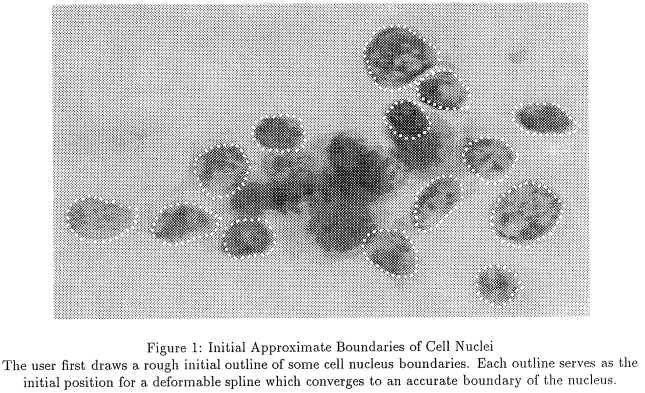

## How is Breast Cancer Usually Detected?

I chose this area of research because about 2.1 million women suffer from breast cancer every year. In addition, breast cancer accounts for a large proportion of all mortality from cancers (~15%). The most common methods for detecting breast cancer are imaging: specifically, mammograms (x-ray picture of breast) and histopathological images.

## What is a Deformable Spline?

In the introductory research papers, investigators used deformable splines. They are active contour models called snakes. The purpose of these models is to solve problems where we already know the approximate shape of the boundary. The user manually traces the approximate boundary to initiate the automated aspect of the process. Snakes adapt to differences and noise in stereo matching and motion tracking. Stereo matching, or disparity estimation, is where we find “pixels in multiscopic [from multiple perspectives or view points] views that correspond to the same 3D point in the scene.” Snakes are often used for shape recognition and edge detection, both of which are extremely important when examining our images. Below is a visual to help see how we merge multiple viewpoints (left and right view) to create an image.

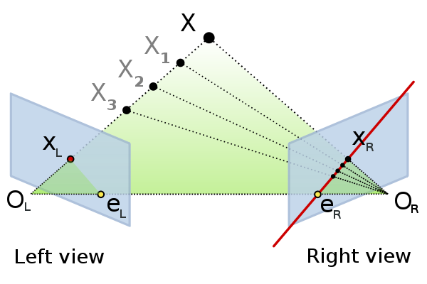

```r
knitr::include_graphics("C:/Users/Carina W Yuen/Downloads/stereo_visual.png")
```

I wanted to explore how snakes are different than classical feature techniques, specifically in the context of Breast Cancer diagnosis.

## Data Source

The data source here is the UCI machine learning repository. Titled “Diagnostic Wisconsin Breast Cancer Database.” There is no missing data.

Link to data: https://archive.ics.uci.edu/dataset/17/breast+cancer+wisconsin+diagnostic

Wolberg,William, Mangasarian,Olvi, Street,Nick, and Street,W.. (1995). Breast Cancer Wisconsin (Diagnostic). UCI Machine Learning Repository. https://doi.org/10.24432/C5DW2B.

# Codebook & EDA

Our data is 569 rows and 32 columns. Of the 32 columns, one of them is the actual diagnosis and the other is id, showing that we actually have 30 predictors in total.

Radius: Found through averaging the length of radial line segments defined by the centroid of the snake and each singular point of the snake, generally a good measure of tumor size

Perimeter: Total distance between snake points, another predictor relating to size

Area: Number of pixels on the interior of the snake plus one-half of the pixels in the perimeter, increased area might indicate cell proliferation, implying a cancerous tumor

Compactness: Measures the compactness of the cell nuclei (dense cell packing) using $perimeter^2/area-1$. Dense cell packing can lead to greater intercellular communication, potentially encouraging the tumor to grow.

Smoothness: Measures the difference between the length of the radial line and the mean length of the lines surrounding it (local variation in radius length)

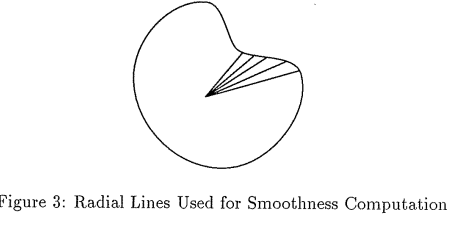

```r
knitr::include_graphics("C:/Users/Carina W Yuen/Pictures/Screenshots/Screenshot (455).png")
```

Concave Points: Measures the number and severity of concavities/indentations in nucleus boundary

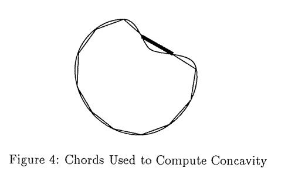

```r
knitr::include_graphics("C:/Users/Carina W Yuen/Pictures/Screenshots/Screenshot (459).png")
```

Symmetry: measures symmetry of nucleus shape, look for irregular symmetry

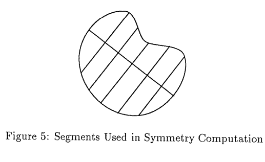

```r
knitr::include_graphics("C:/Users/Carina W Yuen/Pictures/Screenshots/Screenshot (461).png")
```

Fractal Dimension: Perimeter of nucleus measured using coastline approximation by Mandelbrot, helps to characterize complexity and irregularity

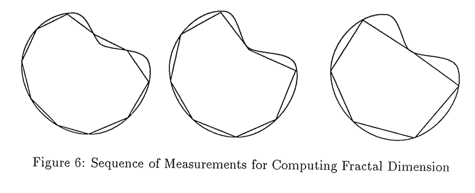

```r
knitr::include_graphics("C:/Users/Carina W Yuen/Pictures/Screenshots/Screenshot (463).png")
```

Texture: Measures variances of the gray scale intensities in component pixels, changes in texture are suspicious

The reason there are 30 predictor columns is because the data consists of mean, se, worst…etc different aspects of the same predictor.

## Histograms For Variables of Interest

After doing some initial exploratory data analysis, it seems that for multiple predictors, the worst case values are all centered more to the right than the mean values. This makes sense as intuitively, as increased tumor size and irregular texture is generally more cause for concern. The suggested background paper confirms this as, “with all the shape features, a higher value corresponds to a less regular contour and thus to a higher probability of malignancy” (Street 5).

Checking for Missing Data Upon inspecting the data set, all the columns have a count of 0 occurrences of NA values, meaning that we do not have any missing data.

```r
colSums(is.na(cancer_data))
```

```
##                      id               diagnosis             radius_mean
##                       0                       0                       0
##            texture_mean          perimeter_mean               area_mean
##                       0                       0                       0
##         smoothness_mean        compactness_mean          concavity_mean
##                       0                       0                       0
##     concave points_mean           symmetry_mean  fractal_dimension_mean
##                       0                       0                       0
##               radius_se              texture_se            perimeter_se
##                       0                       0                       0
##                 area_se           smoothness_se          compactness_se
##                       0                       0                       0
##            concavity_se       concave points_se             symmetry_se
##                       0                       0                       0
##    fractal_dimension_se            radius_worst           texture_worst
##                       0                       0                       0
##         perimeter_worst              area_worst        smoothness_worst
##                       0                       0                       0
##       compactness_worst         concavity_worst    concave points_worst
##                       0                       0                       0
##          symmetry_worst fractal_dimension_worst
##                       0                       0
```

```r
library(tidymodels)
set.seed(123)

# split into training and testing, with only the means
cancer_data_split <- initial_split(cancer_data, prop=0.80, strata=diagnosis)

cancer_data_train <- training(cancer_data_split)
cancer_data_test <- testing(cancer_data_split)
head(cancer_data_train)
```

```
## # A tibble: 6 × 32
##         id diagnosis radius_mean texture_mean perimeter_mean area_mean
##      <dbl> <fct>           <dbl>        <dbl>          <dbl>     <dbl>
## 1  8510426 B               13.5          14.4           87.5      566.
## 2  8510653 B               13.1          15.7           85.6      520
## 3   854941 B               13.0          18.4           82.6      524.
## 4 85713702 B                8.20         16.8           51.7      202.
## 5   857156 B               13.5          22.3           86.9      561
## 6   857373 B               13.6          16.3           87.2      572.
## # ℹ 26 more variables: smoothness_mean <dbl>, compactness_mean <dbl>,
## #   concavity_mean <dbl>, `concave points_mean` <dbl>, symmetry_mean <dbl>,
## #   fractal_dimension_mean <dbl>, radius_se <dbl>, texture_se <dbl>,
## #   perimeter_se <dbl>, area_se <dbl>, smoothness_se <dbl>,
## #   compactness_se <dbl>, concavity_se <dbl>, `concave points_se` <dbl>,
## #   symmetry_se <dbl>, fractal_dimension_se <dbl>, radius_worst <dbl>,
## #   texture_worst <dbl>, perimeter_worst <dbl>, area_worst <dbl>, …
```

```r
# excluding ID and Diagnosis
library(corrplot)
only_predictors <- cancer_data_train %>% select(-c("diagnosis"))
head(only_predictors)
```

```
## # A tibble: 6 × 31
##         id radius_mean texture_mean perimeter_mean area_mean smoothness_mean
##      <dbl>       <dbl>        <dbl>          <dbl>     <dbl>           <dbl>
## 1  8510426       13.5          14.4           87.5      566.          0.0978
## 2  8510653       13.1          15.7           85.6      520           0.108
## 3   854941       13.0          18.4           82.6      524.          0.0898
## 4 85713702        8.20         16.8           51.7      202.          0.086
## 5   857156       13.5          22.3           86.9      561           0.0875
## 6   857373       13.6          16.3           87.2      572.          0.0768
## # ℹ 25 more variables: compactness_mean <dbl>, concavity_mean <dbl>,
## #   `concave points_mean` <dbl>, symmetry_mean <dbl>,
## #   fractal_dimension_mean <dbl>, radius_se <dbl>, texture_se <dbl>,
## #   perimeter_se <dbl>, area_se <dbl>, smoothness_se <dbl>,
## #   compactness_se <dbl>, concavity_se <dbl>, `concave points_se` <dbl>,
## #   symmetry_se <dbl>, fractal_dimension_se <dbl>, radius_worst <dbl>,
## #   texture_worst <dbl>, perimeter_worst <dbl>, area_worst <dbl>, …
```

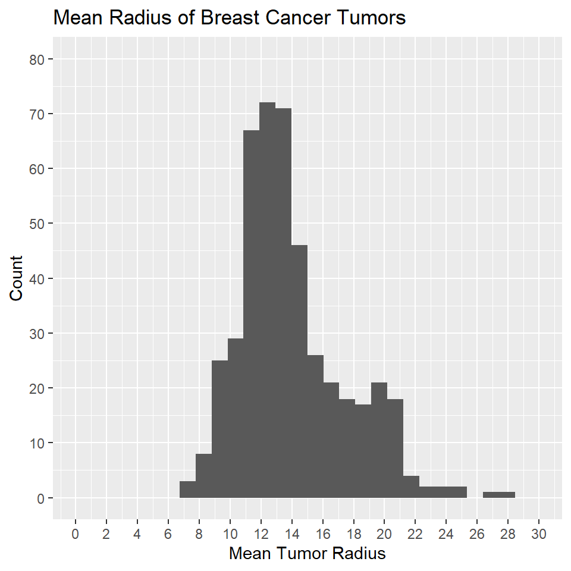

```r
only_mean <- cancer_data_train %>% select(c("radius_mean", "texture_mean",
                                      "perimeter_mean", "area_mean",
                                      "smoothness_mean", "compactness_mean",
                                      "concavity_mean", "concave points_mean",
                                    "symmetry_mean", "fractal_dimension_mean", "diagnosis"))

only_worst <- cancer_data_train %>% select(c("radius_worst", "texture_worst",
                                       "perimeter_worst", "area_worst",
                                       "smoothness_worst", "compactness_worst",
                                       "concavity_worst", "concave points_worst"
                                  , "symmetry_worst", "fractal_dimension_worst"))


# split into categorical and numerical values

mean_radius_plot <- ggplot(only_predictors,aes(x=radius_mean)) +
  geom_histogram()+  scale_y_continuous(breaks = seq(0, 80, by = 10),
limits=c(0,80))+  scale_x_continuous(breaks=seq(0,40, by  = 2), limits=c(0,30))+
labs(title='Mean Radius of Breast Cancer Tumors', x = 'Mean Tumor Radius',  y= 'Count', ylim(0,80), xlim(0,40))
mean_radius_plot
```

Mean Tumor Radius Plot: Here we see that the mean tumor radius is centered around values of 11-16 units of distance from the center to the points on the perimeter. There is a slight right skew to the data.

```r
worst_radius_plot <- ggplot(only_predictors,aes(x=radius_worst)) +
  geom_histogram()+ scale_x_continuous(breaks=seq(0,40, by  = 2), limits=c(0,30))+
  scale_y_continuous(breaks = seq(0, 80, by = 10))+
  labs(title='Worst Radius of Breast Cancer Tumors', x = 'Worst Tumor Radius', y= 'Count', ylim(0,80))
```

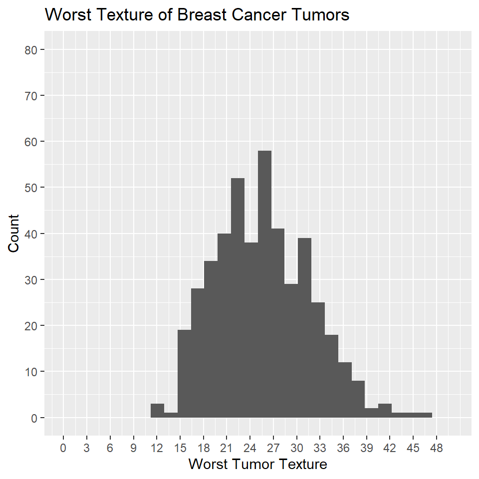

```r
worst_texture_plot <- ggplot(only_predictors, aes(x=texture_worst)) + geom_histogram()  + geom_histogram()+ scale_x_continuous(breaks=seq(0,50, by  = 3), limits=c(0,50))+
  scale_y_continuous(breaks = seq(0, 80, by = 10), limits=c(0,80))+
  labs(title='Worst Texture of Breast Cancer Tumors', x = 'Worst Tumor Texture', y= 'Count', ylim(0,80))

worst_texture_plot
```

Worst Tumor Texture Plot: Here we see that the texture, or the standard deviation of the gray-scale values, are also right skewed. This is an interesting property as it seems that radius (size) and texture have some sort of positive relationship. This can be an avenue for further research!

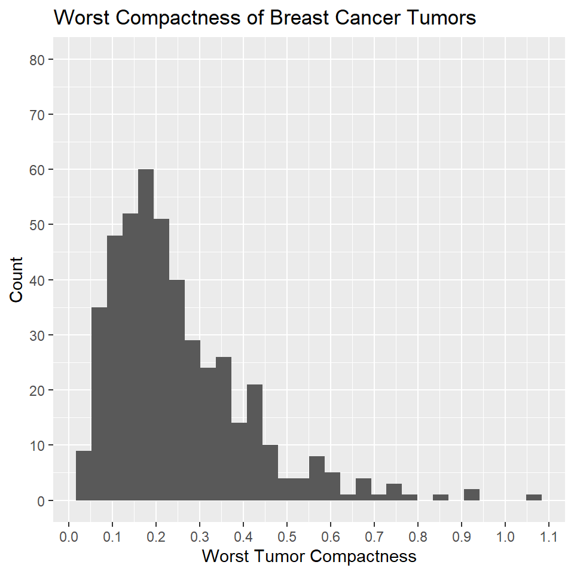

```r
worst_compactness_plot  <- ggplot(only_predictors, aes(x=compactness_worst)) + geom_histogram() + scale_x_continuous(breaks=seq(0,3, by  =0.1))+ scale_y_continuous(breaks = seq(0, 80, by = 10), limits=c(0,80))+labs(title="Worst Compactness of Breast Cancer Tumors", x = "Worst Tumor Compactness", y= "Count", ylim(0,80))
worst_compactness_plot
```

Worst Compactness Plot: The right skew pattern continues! Here we see that the worst tumor compactness is centered around 0.10-0.25. For some background about how these values are derived, the compactness is computed by perimeter^2 / area - 1.0.

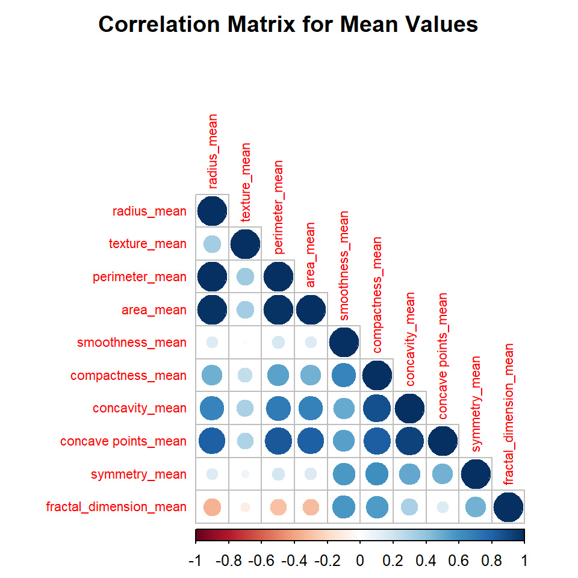

```r
only_mean_wo_diag <- only_mean[1:10]

cor_matrix_mean <- cor(only_mean_wo_diag)

cor_matrix_worst <- cor(only_worst)

corrplot(cor_matrix_mean, tl.cex = 0.7, type = 'lower', title = "Correlation Matrix for Mean Values", mar=c(0,0,2,0))
```

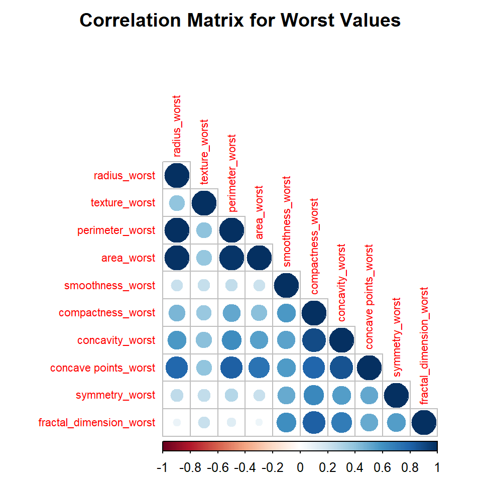

```r
corrplot(cor_matrix_worst, tl.cex = 0.7, type = 'lower', title = "Correlation Matrix for Worst Values", mar=c(0,0,2,0))
```

Splitting the mean data and the worst data allows for more interpretable visualization through the correlation matrix. As expected, the corresponding “matching” predictors (ex: radius_mean vs radius_worst, texture_mean vs texture_worst…etc) all have similar correlation values with the other predictors. A similar strength of relation (represented by shade of circle) is also noted as we compare the corrplot(cor_matrix_mean) and corrplot(cor_matrix_worst).

## Interesting Pattern in Correation Between Predictors and Chances of Malignancy

After examining the covariance plot, some interesting relationships appear between mean concave points and mean radius, and mean compactness and mean concavity. Visually, this is denoted by the darker blue circles which represent the covariance value for each pair of predictors. The positive correlation can be explained by how all the predictors are generally describing size in some manner. The other pairs with strong covariance intuitively make sense, so I choose to explore just the selected pairs.

### Key Insight: Tumor Irregularity and Size

In biology, physical form and structure is often closely related to function. It seems that as the number of indentations in the tumor increase, so does the size. This indicates that larger tumors tend to be more irregular in shape.

## PCA for dimension reduction

The presence of correlated predictors may affect our predictive accuracy. I decided to use PCA to preprocess the data before analyzing it. This way, our analysis more simple to interpret and visualize in the future.

### Examining the Contribution of Each Variable

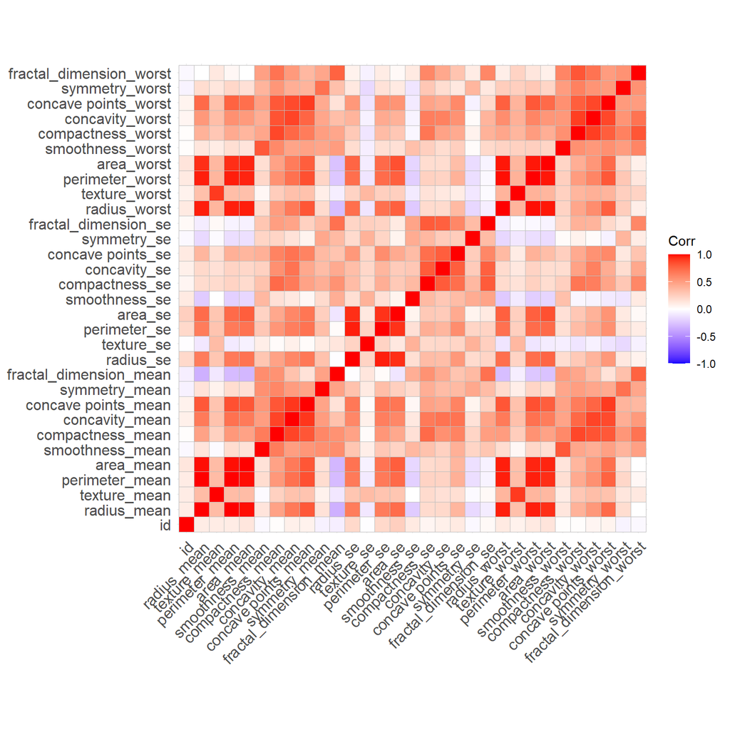

```r
library(factoextra)
library(ggcorrplot)
# normalize data that is numeric
numeric_data <- only_mean %>% select(where(is.numeric))

cancer_data_normalized <- cancer_data_train %>%
  mutate(across(where(is.numeric), scale))

cancer_data_normalized_num <- cancer_data_train %>% select(where(is.numeric))

# create covariance matrix
corr_matrix <- cor(cancer_data_normalized_num)
ggcorrplot(corr_matrix)
```

```r
cancer_data_train.pca <- princomp(corr_matrix)

summary(cancer_data_train.pca)
```

```
## Importance of components:
##                           Comp.1    Comp.2     Comp.3     Comp.4     Comp.5
## Standard deviation     1.2423728 0.7611191 0.44546277 0.32673835 0.24012516
## Proportion of Variance 0.5972388 0.2241555 0.07678334 0.04130897 0.02231102
## Cumulative Proportion  0.5972388 0.8213943 0.89817762 0.93948659 0.96179761
##                           Comp.6      Comp.7     Comp.8      Comp.9     Comp.10
## Standard deviation     0.2126958 0.141635633 0.11398131 0.081081168 0.068630044
## Proportion of Variance 0.0175050 0.007762278 0.00502703 0.002543807 0.001822522
## Cumulative Proportion  0.9793026 0.987064884 0.99209191 0.994635721 0.996458243
##                            Comp.11      Comp.12      Comp.13      Comp.14
## Standard deviation     0.054972474 0.0488752455 0.0414083396 0.0269360371
## Proportion of Variance 0.001169324 0.0009243194 0.0006634677 0.0002807447
## Cumulative Proportion  0.997627567 0.9985518859 0.9992153536 0.9994960983
##                            Comp.15      Comp.16      Comp.17      Comp.18
## Standard deviation     0.024962406 1.535899e-02 1.115413e-02 1.013259e-02
## Proportion of Variance 0.000241111 9.127866e-05 4.814109e-05 3.972694e-05
## Cumulative Proportion  0.999737209 9.998285e-01 9.998766e-01 9.999164e-01
##                             Comp.19      Comp.20      Comp.21      Comp.22
## Standard deviation     7.948886e-03 7.245720e-03 5.690470e-03 4.840012e-03
## Proportion of Variance 2.444875e-05 2.031455e-05 1.252969e-05 9.064356e-06
## Cumulative Proportion  9.999408e-01 9.999611e-01 9.999736e-01 9.999827e-01
##                             Comp.23      Comp.24      Comp.25      Comp.26
## Standard deviation     4.409841e-03 3.234483e-03 2.954062e-03 2.002206e-03
## Proportion of Variance 7.524715e-06 4.048124e-06 3.376629e-06 1.551178e-06
## Cumulative Proportion  9.999902e-01 9.999943e-01 9.999977e-01 9.999992e-01
##                             Comp.27      Comp.28      Comp.29      Comp.30
## Standard deviation     1.367212e-03 3.759191e-04 1.252363e-04 7.171448e-05
## Proportion of Variance 7.232953e-07 5.468057e-08 6.068825e-09 1.990022e-09
## Cumulative Proportion  9.999999e-01 1.000000e+00 1.000000e+00 1.000000e+00
##                        Comp.31
## Standard deviation           0
## Proportion of Variance       0
## Cumulative Proportion        1
```

```r
#biplot(cancer_data_train.pca, rep)

cancer_data_train.pca$loadings[, 1:2]
```

```
##                               Comp.1        Comp.2
## id                       0.023845008  0.1176781374
## radius_mean              0.319937200 -0.0001927997
## texture_mean             0.093618674  0.0949798956
## perimeter_mean           0.313181656 -0.0182624204
## area_mean                0.315234882  0.0137904789
## smoothness_mean         -0.042612528 -0.2251740117
## compactness_mean         0.058256103 -0.2939339345
## concavity_mean           0.134213889 -0.2183442780
## concave points_mean      0.204984068 -0.1623945096
## symmetry_mean           -0.040876423 -0.2089907926
## fractal_dimension_mean  -0.221081385 -0.2850704495
## radius_se                0.186853022  0.0391648615
## texture_se              -0.098788743  0.1493487254
## perimeter_se             0.182554074  0.0176641144
## area_se                  0.229423642  0.0491450538
## smoothness_se           -0.174875456  0.0063933296
## compactness_se          -0.055438462 -0.2350301095
## concavity_se            -0.035883975 -0.1965038081
## concave points_se        0.032135862 -0.1515580996
## symmetry_se             -0.150514277 -0.0167193127
## fractal_dimension_se    -0.148794715 -0.2039821027
## radius_worst             0.317154253 -0.0146964329
## texture_worst            0.093971081  0.0560029337
## perimeter_worst          0.310239224 -0.0349052904
## area_worst               0.310010133  0.0062104599
## smoothness_worst        -0.024148238 -0.2380899608
## compactness_worst        0.058746486 -0.3140681092
## concavity_worst          0.108273908 -0.2806147281
## concave points_worst     0.196176693 -0.2217189188
## symmetry_worst           0.001922136 -0.2296678093
## fractal_dimension_worst -0.087403716 -0.3385466166
```

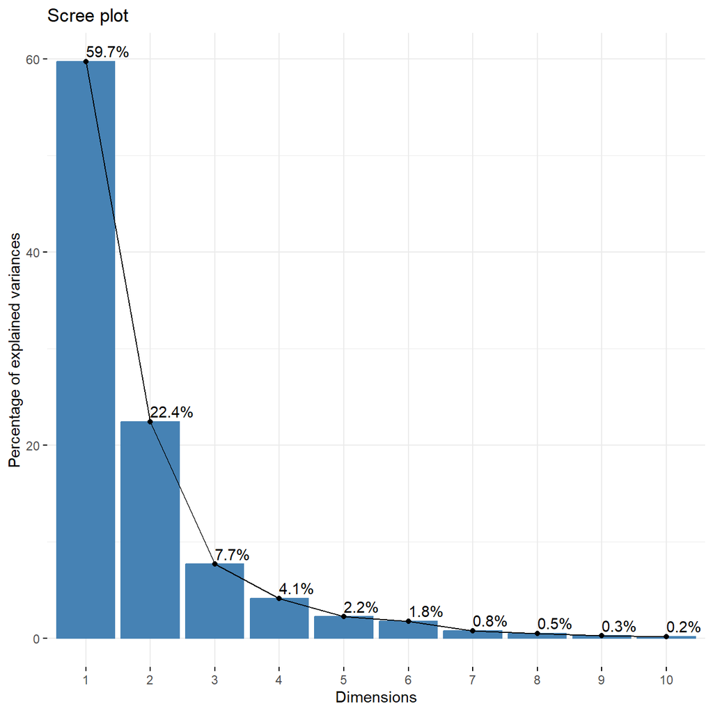

```r
#cancer_data.pca$loadings[, 1:10]
library(factoextra)
# scree plot
fviz_eig(cancer_data_train.pca, addlabels = TRUE)
```

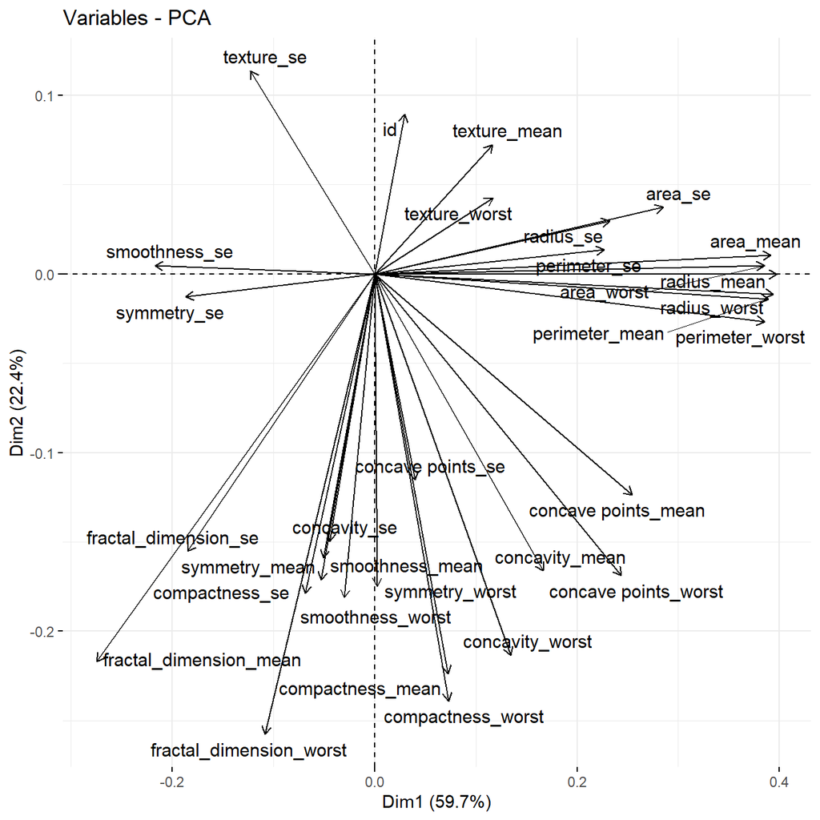

```r
fviz_pca_var(cancer_data_train.pca, addlabels = TRUE, repel = TRUE)
```

Analyzing the bi plot of the attributes, predictors that are grouped together are positively correlated. In the upper right corner, we can see that mean area, mean radius, mean perimeter, and their respective worst values, are in one cluster. Theoretically, it makes sense that these predictors are positively correlated, as they are measuring the same criteria, but different aspects of it, so trends on one criteria generally can apply to trends on the other.

The second group of predictors is near the bottom of the plot. We see mean symmetry, mean smoothness, standard error of concavity, standard error of compactness, worst symmetry, and worst smoothness are clustered together. This provides some useful insight, as intuitive thinking might not let us know that symmetry, smoothness, concavity and compactness are so important.

Examining the scree plot, it is much easier to look at and interpret. We see that 99.6 % of the data’s variance can be explained by the first 10 principal components. This is great, as we started off with 32 columns, 30 of which were predictors! This is a significant reduction in dimension!

# Model Building

## Model 1: Pruned Decision Tree

The first model I chose was the Pruned Decision Tree. I chose this model because the pruning process has the potential to help with overfitting. In addition, it simplifies the decision tree for better interpretability. Decision trees in general are advantageous because we are doing automatic feature selection. It also works great for larger data sets. In this case, I have about 560 observations, so computational cost is not a huge consideration. However, if my data set was larger, this would also still work well.

```r
library(rpart.plot)
cancer_folds <- vfold_cv(cancer_data_train, v = 10)

tree_spec <- decision_tree(cost_complexity=tune()) %>%
  set_engine("rpart") %>%
  set_mode("classification")

c_recipe <- recipe(diagnosis~., data=cancer_data_train)%>%
  step_dummy(all_nominal_predictors()) %>%
  step_center(all_numeric_predictors()) %>%
  step_scale(all_numeric_predictors()) %>%
  step_pca()

c_recipe  %>% prep() %>% bake(new_data=cancer_data_train)
```

```
## # A tibble: 454 × 32
##        id radius_mean texture_mean perimeter_mean area_mean smoothness_mean
##     <dbl>       <dbl>        <dbl>          <dbl>     <dbl>           <dbl>
##  1 -0.188      -0.133      -1.16           -0.150    -0.224          0.121
##  2 -0.188      -0.267      -0.837          -0.227    -0.360          0.806
##  3 -0.246      -0.281      -0.195          -0.355    -0.349         -0.441
##  4  0.391      -1.68       -0.569          -1.66     -1.30          -0.711
##  5 -0.246      -0.148       0.725          -0.173    -0.239         -0.604
##  6 -0.246      -0.104      -0.688          -0.161    -0.207         -1.36
##  7 -0.246      -0.597      -0.237          -0.647    -0.602         -0.950
##  8  0.391      -0.719      -0.117          -0.747    -0.687         -0.0592
##  9 -0.246      -0.275       0.0161         -0.355    -0.339         -1.09
## 10 -0.246      -1.56       -1.77           -1.55     -1.23           0.102
## # ℹ 444 more rows
## # ℹ 26 more variables: compactness_mean <dbl>, concavity_mean <dbl>,
## #   `concave points_mean` <dbl>, symmetry_mean <dbl>,
## #   fractal_dimension_mean <dbl>, radius_se <dbl>, texture_se <dbl>,
## #   perimeter_se <dbl>, area_se <dbl>, smoothness_se <dbl>,
## #   compactness_se <dbl>, concavity_se <dbl>, `concave points_se` <dbl>,
## #   symmetry_se <dbl>, fractal_dimension_se <dbl>, radius_worst <dbl>, …
```

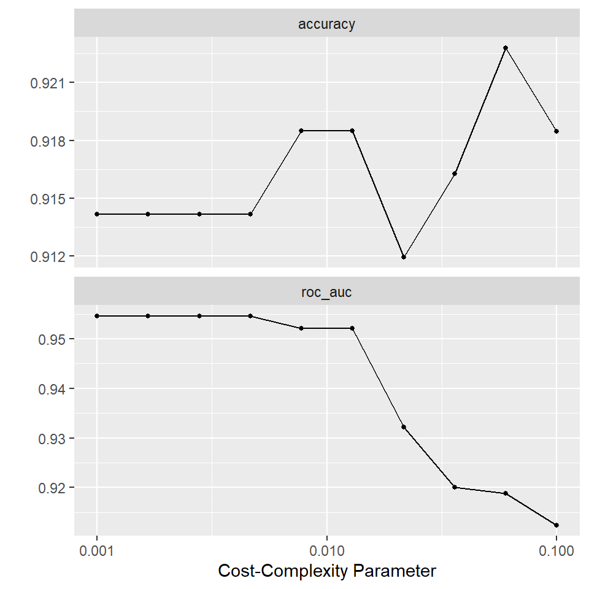

```r
tree_wf <- workflow() %>%
  add_model(tree_spec) %>%
  add_recipe(c_recipe)

param_grid <- grid_regular(cost_complexity(range=c(-3, -1)), levels=10)

tune_tree <- tune_grid(
  tree_wf,
  resamples = cancer_folds,
  grid = param_grid
)

autoplot(tune_tree)
```

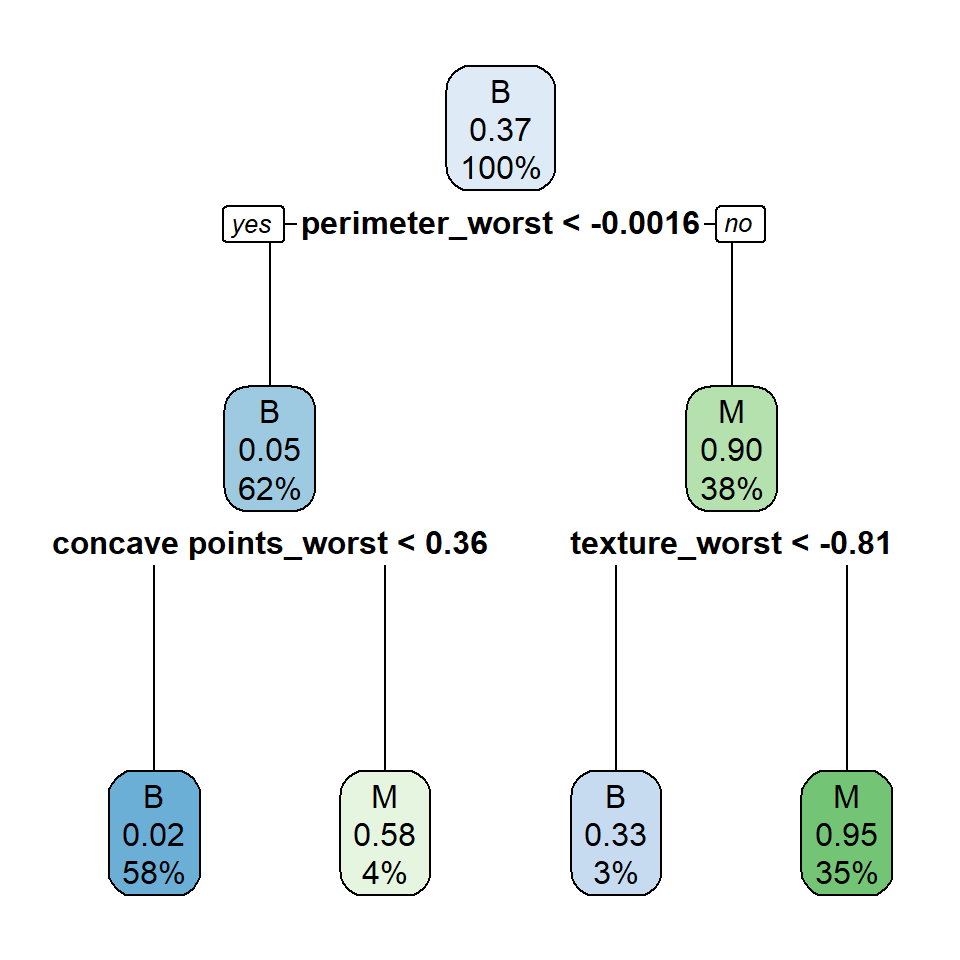

```r
# to choose the best model
best_complexity <- select_best(tune_tree)
tree_final <- finalize_workflow(tree_wf, best_complexity)
tree_fin_fit <- fit(tree_final, data=cancer_data_train)

tree_fin_fit %>%
  extract_fit_engine() %>%
  rpart.plot()
```

```r
best_complexity
```

```
## # A tibble: 1 × 2
##   cost_complexity .config
##             <dbl> <chr>
## 1           0.001 Preprocessor1_Model01
```

The best cost complexity value was 0.001. Cost Complexity parameters represent the trade-off between tree complexity and quality of fit. This value hints there is a small penalty for complexity when tuning. This suggests that there is value in increasing the complexity of our model, up to a certain point.

### Pruned Decision Tree Performance

Unfortunately, this model did not do as good as I expected. Upon further reading about the Pruned Decision Tree model, I believe this might be because of under fitting. Since the process involves the removal of branches, we do lose some information from the data as a result.

## Model 2: KNN

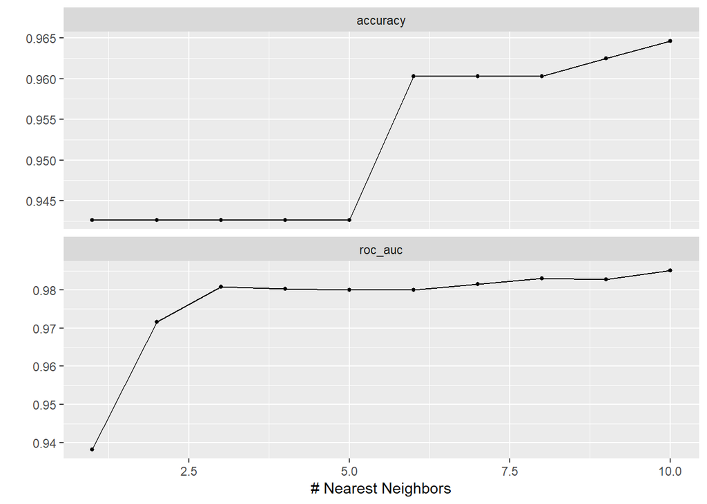

```r
library(parsnip)
knn_mod_cv <- nearest_neighbor(neighbors = tune()) %>%
  set_mode("classification") %>%
  set_engine("kknn")

# with cross validation
knn_wkflow_cv <- workflow() %>%
  add_model(knn_mod_cv) %>%
  add_recipe(c_recipe)

# create k fold data set
cancer_folds <- vfold_cv(cancer_data_train, v = 10)

# create and tune grid
neighbors_grid <- grid_regular(neighbors(range = c(1,10)), levels = 10)

tune_res <- tune_grid(object = knn_wkflow_cv, resamples = cancer_folds, grid = neighbors_grid, control = control_grid((verbose=TRUE)))
autoplot(tune_res)
```

```r
collect_metrics(tune_res)
```

```
## # A tibble: 20 × 7
##    neighbors .metric  .estimator  mean     n std_err .config
##        <int> <chr>    <chr>      <dbl> <int>   <dbl> <chr>
##  1         1 accuracy binary     0.943    10 0.0148  Preprocessor1_Model01
##  2         1 roc_auc  binary     0.938    10 0.0159  Preprocessor1_Model01
##  3         2 accuracy binary     0.943    10 0.0148  Preprocessor1_Model02
##  4         2 roc_auc  binary     0.972    10 0.00864 Preprocessor1_Model02
##  5         3 accuracy binary     0.943    10 0.0148  Preprocessor1_Model03
##  6         3 roc_auc  binary     0.981    10 0.00747 Preprocessor1_Model03
##  7         4 accuracy binary     0.943    10 0.0148  Preprocessor1_Model04
##  8         4 roc_auc  binary     0.980    10 0.00781 Preprocessor1_Model04
##  9         5 accuracy binary     0.943    10 0.0148  Preprocessor1_Model05
## 10         5 roc_auc  binary     0.980    10 0.00777 Preprocessor1_Model05
## 11         6 accuracy binary     0.960    10 0.00921 Preprocessor1_Model06
## 12         6 roc_auc  binary     0.980    10 0.00783 Preprocessor1_Model06
## 13         7 accuracy binary     0.960    10 0.00921 Preprocessor1_Model07
## 14         7 roc_auc  binary     0.981    10 0.00736 Preprocessor1_Model07
## 15         8 accuracy binary     0.960    10 0.00921 Preprocessor1_Model08
## 16         8 roc_auc  binary     0.983    10 0.00627 Preprocessor1_Model08
## 17         9 accuracy binary     0.962    10 0.00937 Preprocessor1_Model09
## 18         9 roc_auc  binary     0.983    10 0.00636 Preprocessor1_Model09
## 19        10 accuracy binary     0.965    10 0.00889 Preprocessor1_Model10
## 20        10 roc_auc  binary     0.985    10 0.00564 Preprocessor1_Model10
```